# Cardio Good Fitness Project! - by Vanika Hans

The purpose of this project is to explore the given dataset to identify overall patterns, come up with a customer profile for each product, perform uni-, bi-, and multi-variate analysis, and most of all gain exposure to Python while applying several concepts covered so far in class. The goal is to eventually identify differences between customers of each product and provide recommendations to the company. The dataset contains the following:

- Product - the model no. of the treadmill
- Age - in no of years, of the customer
- Gender - of the customer
- Education - in no. of years, of the customer
- Marital Status - of the customer
- Usage - Avg. # times the customer wants to use the treadmill every week
- Fitness - Self rated fitness score of the customer (5 - very fit, 1 - very unfit)
- Income - of the customer
- Miles- expected to run

We will begin the analysis by setting up basic necessary libraries in the notebook:

### 1] Import the libraries

```python
import pandas as pd
import numpy as np
import seaborn as sns
import matplotlib.pyplot as plt
%matplotlib inline
import warnings
warnings.filterwarnings('ignore')
pd.set_option('display.float_format', lambda x: '%.5f' % x) # To suppress numerical display in scientific notations
```

### 2] Input the data

```python
cardiodata = pd.read_csv('CardioGoodFitness.csv')
```

### 3] Check if any gaps in the data

```python
cardiodata.isnull().sum()
#data = data.dropna() # drops all missing values in the data -- NOT NECESSARY BC SUM IS 0
```

```
Product          0
Age              0
Gender           0
Education        0
MaritalStatus    0
Usage            0
Fitness          0
Income           0
Miles            0
dtype: int64
```

### 4] Gather initial data - head, shape, info

```python
cardiodata.head(10)
```

|  | Product | Age | Gender | Education | MaritalStatus | Usage | Fitness | Income | Miles |
| --- | --- | --- | --- | --- | --- | --- | --- | --- | --- |
| 0 | TM195 | 18 | Male | 14 | Single | 3 | 4 | 29562 | 112 |
| 1 | TM195 | 19 | Male | 15 | Single | 2 | 3 | 31836 | 75 |
| 2 | TM195 | 19 | Female | 14 | Partnered | 4 | 3 | 30699 | 66 |
| 3 | TM195 | 19 | Male | 12 | Single | 3 | 3 | 32973 | 85 |
| 4 | TM195 | 20 | Male | 13 | Partnered | 4 | 2 | 35247 | 47 |
| 5 | TM195 | 20 | Female | 14 | Partnered | 3 | 3 | 32973 | 66 |
| 6 | TM195 | 21 | Female | 14 | Partnered | 3 | 3 | 35247 | 75 |
| 7 | TM195 | 21 | Male | 13 | Single | 3 | 3 | 32973 | 85 |
| 8 | TM195 | 21 | Male | 15 | Single | 5 | 4 | 35247 | 141 |
| 9 | TM195 | 21 | Female | 15 | Partnered | 2 | 3 | 37521 | 85 |

```python
cardiodata.shape
```

```
(180, 9)
```

```python
cardiodata.dtypes
```

```
Product          object
Age               int64
Gender           object
Education         int64
MaritalStatus    object
Usage             int64
Fitness           int64
Income            int64
Miles             int64
dtype: object
```

#### Observations:

Qualitative data: Product (type of treadmill), Gender, Marital Status  
Quantitative data: Age, Education, Usage, Fitness, Income, Miles

### 5] Creating functions for easy access in analysis:

```python
def pretty_distribution_curve(dataset,series):
    f, (ax_box,ax_hist) = plt.subplots(2, sharex=True, gridspec_kw= {"height_ratios": (0.2, 1)})
    mean=dataset[series].mean()
    median=dataset[series].median()
    mode=dataset[series].mode().tolist()[0]
    sns.boxplot(dataset[series], ax=ax_box)
    ax_box.axvline(mean, color='r', linestyle='--')
    ax_box.axvline(median, color='g', linestyle='-')
    ax_box.axvline(mode, color='b', linestyle='-')
    sns.distplot(dataset[series],ax=ax_hist).set_title(series)
    ax_hist.axvline(mean, color='r', linestyle='--',label="mean")
    ax_hist.axvline(median, color='g', linestyle='-',label="median")
    ax_hist.axvline(mode, color='b', linestyle='-',label="mode")
    plt.legend()
    plt.show()

# plt.figure(figsize=(20,10)) # makes the plot wider
#plt.hist(data, color='g') # plots a simple histogram ## this line is where we get 4.81 and 9.62 numbers
#plt.axvline(data.mean(), color='m', linewidth=1)
#plt.axvline(data.median(), color='b', linestyle='dashed', linewidth=1)
#plt.axvline(data.mode()[0], color='w', linestyle='dashed', linewidth=1)
```

### 5] UNIVARIATE ANALYSIS: Initial insight onto overall data:

```python
cardiodata.describe()
```

|  | Age | Education | Usage | Fitness | Income | Miles |
| --- | --- | --- | --- | --- | --- | --- |
| count | 180.00000 | 180.00000 | 180.00000 | 180.00000 | 180.00000 | 180.00000 |
| mean | 28.78889 | 15.57222 | 3.45556 | 3.31111 | 53719.57778 | 103.19444 |
| std | 6.94350 | 1.61705 | 1.08480 | 0.95887 | 16506.68423 | 51.86360 |
| min | 18.00000 | 12.00000 | 2.00000 | 1.00000 | 29562.00000 | 21.00000 |
| 25% | 24.00000 | 14.00000 | 3.00000 | 3.00000 | 44058.75000 | 66.00000 |
| 50% | 26.00000 | 16.00000 | 3.00000 | 3.00000 | 50596.50000 | 94.00000 |
| 75% | 33.00000 | 16.00000 | 4.00000 | 4.00000 | 58668.00000 | 114.75000 |
| max | 50.00000 | 21.00000 | 7.00000 | 5.00000 | 104581.00000 | 360.00000 |

**OBSERVATION 1:** Average overall **AGE** is 28. Data is right-skewed (mean > median). Age group ranges from 18 (min) to 50 (max).  
**OBSERVATION 2:** Average overall **EDUCATION** is 15 years.  
**OBSERVATION 3:** Average overall **USAGE** is 3.4 times a week.  
**OBSERVATION 4:** Average overall **FITNESS SCORE** is 3.3.  
**OBSERVATION 5:** **INCOME** has a very high standard deviation ie spread of data and is right-skewed (mean > median). This implies that although average income is 53k and the middle 50% of folks are at 44k-58k, there's a large range of folks with higher income that purchase treadmills. Folks with an income lower than 29.5k do not purchase treadmills.  
**OBSERVATION 6:** **MILES** has a very high standard deviation ie spread of data and is right-skewed (mean > median).

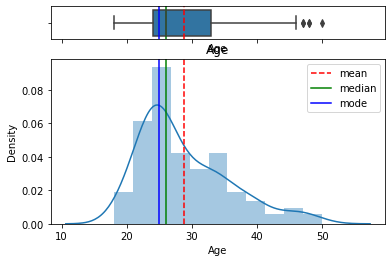

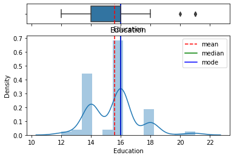

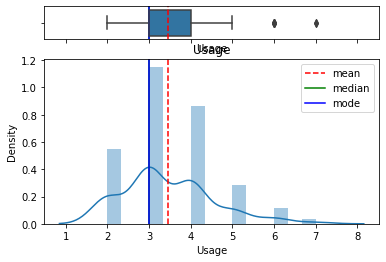

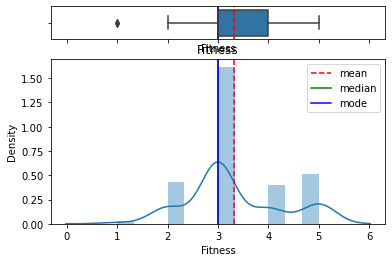

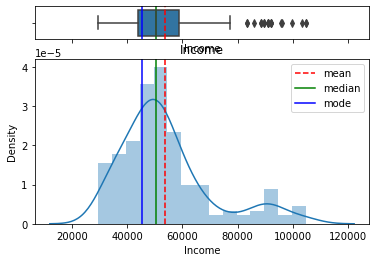

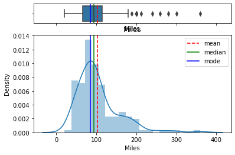

```python
pretty_distribution_curve(cardiodata,"Age")
pretty_distribution_curve(cardiodata,"Education")
pretty_distribution_curve(cardiodata,"Usage")
pretty_distribution_curve(cardiodata,"Fitness")
pretty_distribution_curve(cardiodata,"Income")
pretty_distribution_curve(cardiodata,"Miles")
```

**Ask is to analyze datasets to find differences between customers of each product. So let us explore what different products there are.**